# Chapter6_出国留学数据

# 1 设置绘图主题

# 2 留学申请数据集

## 2.1 读入数据

```r
> # 读取原始数据
> descriptive <- read.csv("data\\Data_Cleaning.csv", header = T, stringsAsFactors = F,fileEncoding = "utf-8")
> # 将数据按照变量index_origin（原始编号）排序
> descriptive <- descriptive[order(descriptive$index_origin),]
```

## 2.2 调整变量类型

```r
> table(descriptive$offertype)
```

```
                 AD无奖      AD小奖       Offer         Rej WaitingList
          1        8804         956        1610        4538         306
```

```r
> #不考虑录取的奖学金，均归入“Admitted“（录取）
> descriptive$offertype[descriptive$offertype %in% c("AD小奖", "Offer", "AD无奖")] <- "Admitted"
> descriptive$offertype[descriptive$offertype == "Rej"] <- "Rejected"
```

```r
> #删去缺失录取结果的样本
> descriptive <- descriptive[-which(descriptive$offertype == ""),]
```

## 2.3 绘制饼状图

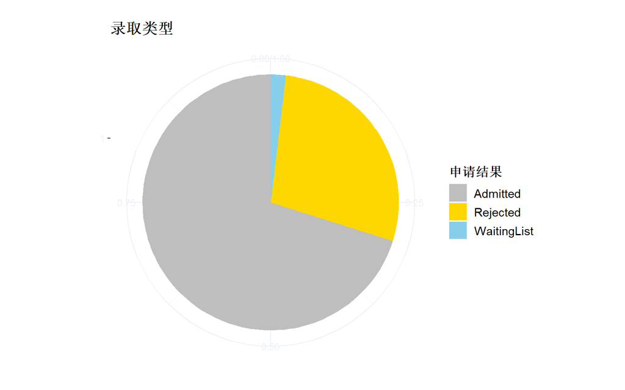

```r
> (piechart1 <- ggplot(descriptive, aes(x = factor(1), fill = factor(offertype))) +
+     geom_bar(position = "fill", width = 1) +
+     scale_fill_manual("申请结果", values = c("grey","gold","skyblue")) +
+     coord_polar(theta = "y") +
+     labs(x = "", y = "", title = "\n录取类型") +
+     plot_theme_pie)
```

## 2.4 最热门的top10申请学校

由于数据存在错误，我们需要对申请学校这一变量进行简单修正：将学校名”Texas A”、“M University”替换”Texas A&M University”，将”Washington University in St”、”Louis”替换为”Washington University in St. Louis”。随后，为了统一申请学校名称，我们要将学校缩写替换为全称，得到的新变量College_apply_new 并入原数据（注意：不考虑缩写字母的大小写差异，需要借助文件美国大学缩写汇总.txt）。根据统一后的学校名称，找出申请人数最多的10所热门学校。

### 2.4.1 修正学校名称

```r
> descriptive$college_apply[descriptive$college_apply %in% c("Texas A", "M University")] <- "Texas A&M University"
> descriptive$college_apply[descriptive$college_apply %in% c("Washington University in St", " Louis")] <- "Washington University in St. Louis"
```

### 2.4.2 统一学校名称

```r
> # 读入常见的美国大学缩写汇总
> SuoXie <- read.table("data\\美国大学缩写汇总.txt", header = T)
> # 设置初始值
> college_apply_new <- NULL
> # 不考虑大小写差异（下同）
> college_low <- tolower(descriptive$college_apply)
> suoxie_low <- tolower(SuoXie$ysuoxie)
> # 统一全称和缩写
> (dim(descriptive))
```

```
[1] 16214    32
```

```r
> for(i in 1:dim(descriptive)[1]){
+   if (college_low[i] %in% suoxie_low) {
+     college_apply_new[i] <- as.character(SuoXie$yquancheng[suoxie_low %in% college_low[i]])
+   } else college_apply_new[i] <- descriptive$college_apply[i]
+ }
> # 统一学校名称后的新变量
> descriptive$College_apply_new <- college_apply_new
```

```r
> # 找出10大热门学校
> (top10_college_apply <- names(sort(table(descriptive$College_apply_new),decreasing = T)[c(1:10)]))
```

```
 [1] "University of California"
 [2] "Carnegie Mellon University"
 [3] "University of Southern California"
 [4] "Columbia University"
 [5] "University of Pennsylvania"
 [6] "Northeastern University"
 [7] "University of Illinois at Urbana-Champaign"
 [8] "University of Michigan"
 [9] "Cornell University"
[10] "Texas A&M University"
```

## 2.5 申请GPA对录取结果的影响

(注意：为简化后续分析，删掉所有录取结果为 WaitingList 的样本，只保留15908条数据)

```r
> descriptive <- descriptive[-which(descriptive$offertype == "WaitingList"),]
```

GPA（标准化考试成绩）是申请的关键之一。用变量gpa除以分制变量gpa_measure，再乘以4.0，可以将GPA标准化为四分制，得到新变量Standardgap并入原数据。考虑到不同排名的学校对学生成绩的要求差异，对申请学校进行排名划分。读入“QS大学排名前百（美国）.txt”，数据集前19所学校是世界前五十名的美国名校，据此将所有申请学校划分为”Top50”和”Others”两类，得到因子型的新变量CollegeRankTop50并入原数据。

(1)按学校名称匹配大学排名

```r
> # 读入QS世界大学排名
> universities <- read.table("data\\QS大学排名前百（美国）.txt",header = F, sep="\n")$V1
> top50university <- NULL # 变量初始化
> for(i in 1:dim(descriptive)[1]){
+   top50university[i] <- descriptive$College_apply_new[i] %in% universities[1:19] # 共19所美国名校进入世界前五十名
+   }
> # 整理变量
> collegerank <- rep("Others",dim(descriptive)[1])
> # 大学排名前50
> collegerank[top50university] <- "Top50"
> # 并入原数据
> descriptive$CollegeRankTop50 <- collegerank
```

(2)gpa标准化

```r
> # 将gpa统一整理为4分制
> descriptive$Standardgap <- (descriptive$gpa/descriptive$gpa_measure)*4
> gpa_offertype <- descriptive[, c("Standardgap", "offertype", "CollegeRankTop50")]
> # 调整因子水平
> gpa_offertype$offertype <- factor(gpa_offertype$offertype, levels = c("Admitted", "Rejected"),labels = c("录取","被拒"))
> gpa_offertype$CollegeRankTop50 <- factor(gpa_offertype$CollegeRankTop50, levels = c("Top50","Others"))
```

接着，考查学业成绩Standardgap和学校排名CollegeRankTop50对录取结果的影响。绘制成绩与申请结果箱线图，并谈谈你的发现。注意，从现实出发，只画出Standardgap>2.0的样本。

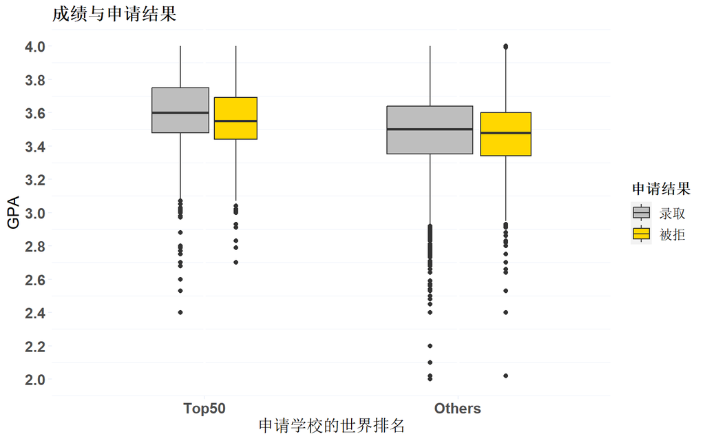

```r
> # 画图
> (boxplot1 <- ggplot(gpa_offertype, aes(x = factor(CollegeRankTop50), y = Standardgap, fill = factor(offertype))) +
+     geom_boxplot(show.legend = T, varwidth = T) +
+     scale_fill_manual("申请结果", values = c("grey", "gold")) +
+     scale_y_continuous(limits = c(2, 4),breaks = seq(2, 4, by = 0.2))+    # 不考虑gpa<2.0的样本
+     labs(x = "申请学校的世界排名", y = "GPA", title = "成绩与申请结果") +
+     plot_theme)
```

最后，将成绩划分为”<=3.4”, “3.4-3.55”, “3.55-3.7”, “>3.7”四类，得到新变量gpa_dis并入原数据。

```r
> descriptive$gpa_dis <- cut(descriptive$Standardgap, breaks = c(0, 3.4, 3.55, 3.7, Inf),labels = c("<=3.4", "3.4~3.55", "3.55~3.7", ">3.7"))
```

## 2.6 托福成绩对于申请结果的影响

托福成绩也是申请时至关重要的一环。将变量toefl转化为数值变量，随后划分为”<=98”, “98-102”, “102-106”, “>106”四个分数段，得到因子型的新变量toefl_dis并入数据。计算不同排名的学校在各分数段的录取率，绘制复式条形图。注意标注出录取率百分数，并添加一条平均录取率作为参考线。

```r
> # 将托福成绩信息变为数值型
> descriptive$toefl <- as.numeric(descriptive$toefl)
> descriptive$toefl_dis <- cut(descriptive$toefl, breaks = c(0, 98, 102, 106, Inf),labels = c("<=98", "98~102", "102~106", ">106"))
```

```r
> # 计算录取率
> ifadmitted <- ifelse(descriptive$offertype == "Admitted",1,0)
> admittedPct <- aggregate(ifadmitted, list(descriptive$toefl_dis, descriptive$CollegeRankTop50), mean)
> colnames(admittedPct) <- c("TOEFL","学校排名","admittedpct")
> admittedPct$学校排名 <- factor(admittedPct$学校排名,levels = c("Top50","Others"))
```

[figure not shown]

```r
> # 画图
> (barplot2 <- ggplot(admittedPct, aes(TOEFL, admittedpct, fill = 学校排名)) +
+   geom_bar(stat='identity',position='dodge') +
+   scale_fill_manual("学校排名", values = c("grey", "gold")) +
+   labs(x="", y="", title="\n不同托福成绩的平均录取率") +
+   geom_text(label = paste(round(admittedPct[order(admittedPct$TOEFL), 3], 2)*100, "%", sep=''), colour = "black", position = position_dodge(1), size = 3, vjust =-0.8)+
+   geom_hline(aes(yintercept = mean(ifadmitted)), col = "orange", lwd = 1)+
+   geom_text(label = paste(round(mean(ifadmitted), 2)*100, "%", sep=''), colour = "orange",x = 5.4, y = 0.7, size = 5.7, vjust =  - 0.5) +
+   plot_theme)
```

## 2.7 硬件条件对于不同学位申请的情况

```r
> library(reshape2)
> # 预处理
> descriptive$first <- abs(descriptive$first)
> descriptive$sci <- abs(descriptive$sci)
> # 录取情况与硬件条件
> extra_offertype <- descriptive[, c("rl", "intern", "research", "paper", "first", "sci", "exchange", "type")]
> tab1 <- table(extra_offertype$type)
> tab1
```

```
   MS   PhD  混合
13286  2394   228
```

```r
> ## 短表变长表
> extra_offertype <- melt(extra_offertype, id = "type")
> count <- subset(extra_offertype, extra_offertype$value == 1)
> ## 申请硕博拥有某硬件条件的情况
> tab2 <- table(count$type, count$variable)
> tab2
```

```
         rl intern research paper first  sci exchange
  MS    290   2441     1703   859   699  578      374
  PhD   131    146      313   535   427  354       84
  混合   11     13       28    36    31   25        7
```

```r
> ## 学位×硬件条件
> count_plot <- melt(rbind(tab2[1, ]/tab1[1], tab2[2, ]/tab1[2],  tab2[3, ]/tab1[3]))
> colnames(count_plot)[1:2] <- c("X1", "X2")
> ## 调整变量因子水平
> count_plot$X1 <- factor(count_plot$X1, levels = c(1, 2, 3), labels = c("MS", "PhD", "混合"))
> count_plot$X2 <- factor(count_plot$X2, levels = c("research","paper","first","sci","rl","intern","exchange"),labels = c("科研", "论文", "一作", "SCI论文", "牛推", "实习", "交换"))
```

绘制硬件条件与申请学位的矩阵图

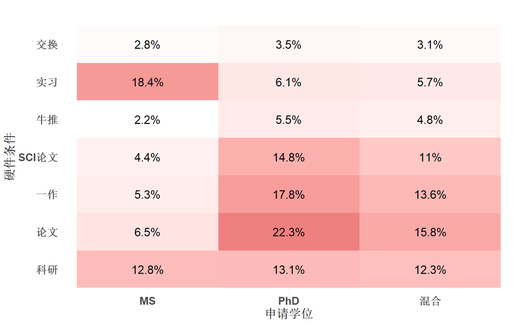

```r
> (matrix1 <- ggplot(count_plot, aes(x = X1, y = X2, label = value, fill = value)) +
+     geom_tile(show.legend = F) +
+     geom_text(label = paste(round(count_plot$value, 3)*100, "%", sep = ''),
+               color = "black", size = 4.5) +
+     scale_fill_gradient("count", low = "white", high = "lightCoral") +
+     labs(x = "申请学位", y = "硬件条件", title = "") + plot_theme)
```

## 2.8 模型建立与选择

```r
> descriptive$offertype <- factor(descriptive$offertype, levels = c("Admitted", "Rejected"))
```

### 2.8.1 建立回归方程

```r
> formula <- "offertype ~ season + type + cross + rl + intern + research + paper + first + sci + exchange + CollegeRankTop50 + gpa_dis + toefl_dis"
```

### 2.8.2 抽取训练集

```r
> set.seed(1234)
> nsample <- sample(x = dim(descriptive)[1], size = dim(descriptive)[1]/5, replace = F)
> # 重新划分训练集和测试集
> descriptive_train <- descriptive[-nsample, ]
> descriptive_test <- descriptive[nsample, ]
```

```r
> # 建立逻辑回归模型
> myglm0 <- glm(formula, family = binomial(link = "logit"), data = descriptive_train)
```

```r
> # 逐步回归
> myglm <- step(myglm0, trace = F)
> summary(myglm)
```

```
Call:
glm(formula = offertype ~ season + type + cross + intern + research +
    paper + sci + exchange + CollegeRankTop50 + gpa_dis + toefl_dis,
    family = binomial(link = "logit"), data = descriptive_train)

Coefficients:
                      Estimate Std. Error z value Pr(>|z|)
(Intercept)           -0.93725    0.05501 -17.036  < 2e-16 ***
seasonSpring          -0.60585    0.17403  -3.481 0.000499 ***
typePhD                0.12936    0.06801   1.902 0.057144 .
type混合              -0.20011    0.20368  -0.982 0.325855
cross                  0.16464    0.05809   2.834 0.004594 **
intern                 0.09656    0.06055   1.595 0.110782
research               0.20227    0.06707   3.016 0.002564 **
paper                 -0.19493    0.08362  -2.331 0.019748 *
sci                   -0.19950    0.09938  -2.008 0.044692 *
exchange              -0.73152    0.14850  -4.926 8.39e-07 ***
CollegeRankTop50Top50  0.56726    0.04850  11.695  < 2e-16 ***
gpa_dis3.4~3.55       -0.01246    0.05856  -0.213 0.831454
gpa_dis3.55~3.7       -0.23086    0.06219  -3.712 0.000205 ***
gpa_dis>3.7           -0.40755    0.06966  -5.850 4.90e-09 ***
toefl_dis98~102        0.05808    0.06240   0.931 0.351984
toefl_dis102~106      -0.01725    0.06343  -0.272 0.785626
toefl_dis>106         -0.18947    0.07032  -2.695 0.007048 **
---
Signif. codes:  0 '***' 0.001 '**' 0.01 '*' 0.05 '.' 0.1 ' ' 1

(Dispersion parameter for binomial family taken to be 1)

    Null deviance: 12122  on 9976  degrees of freedom
Residual deviance: 11871  on 9960  degrees of freedom
  (因为不存在，2750个观察量被删除了)
AIC: 11905

Number of Fisher Scoring iterations: 4
```

## 2.9 模型预测

```r
> library(pROC)
```

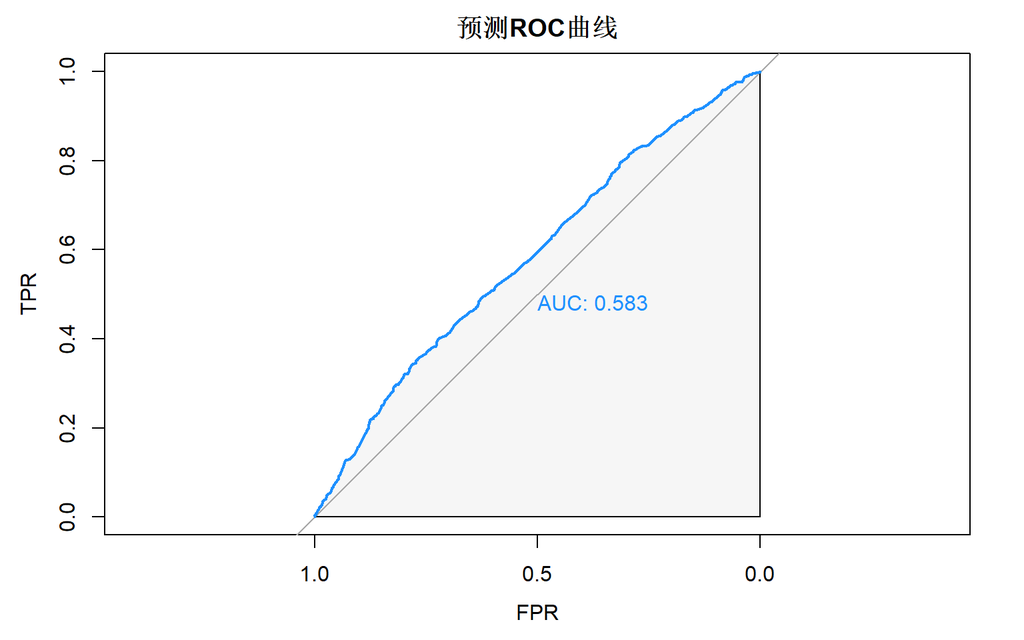

```r
> # 进行预测
> pred <- predict(myglm, descriptive_test, type="response")
> # 绘制ROC曲线
> plot.roc(descriptive_test$offertype, pred, col = "dodgerblue", print.auc=TRUE,auc.polygon=TRUE, auc.polygon.col="#f6f6f6", xlab = "FPR",ylab = "TPR", main = "预测ROC曲线")
```